# FIE5-2-IOS-4-Devoir-4

Julia Ricchi & Chiara Soulié

2026-05-14

# Étude de cas : Analyse et modélisation des flux de patients en urologie

## Introduction

Ce rapport s’inscrit dans le cadre de l’analyse du fonctionnement d’un plateau mutualisé de consultations externes au sein d’un service hospitalier d’urologie. L’objectif principal est de construire une modélisation réaliste et simulable du service, en nous appuyant sur des données de traçabilité patient collectées via des étiquettes électroniques de type RFID le 12/11/2015. Ces données, fusionnées avec les informations des systèmes d’information administratifs et médicaux, constituent le fichier de log sur lequel repose l’ensemble de notre analyse.

La figure ci-dessous présente le plan du plateau de consultations (voir fichiers PlanConsultations.pdf et ZoomURO.pdf disponibles sur http://bit.ly/PlansCHUTlse).

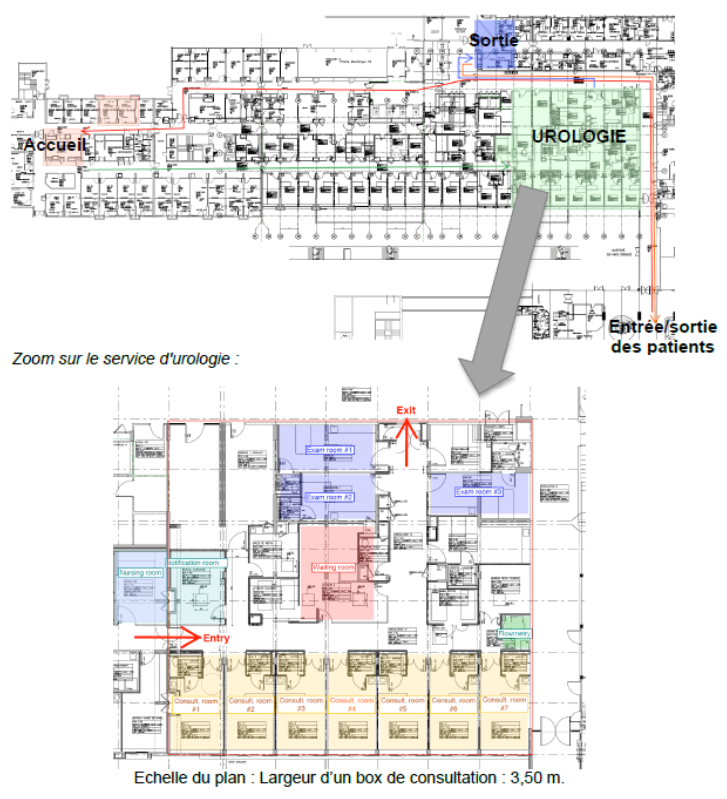

Plan du plateau de consultations

Les colonnes du fichier de données sont les suivantes :

- *ID* (Col A) : Identifiant anonymisé du patient
- *Timestamp start* (Col B) : Horodatage d’entrée dans une zone ou salle
- *Timestamp end* (Col C) : Horodatage de sortie de la zone ou salle
- *Activity_MACRO* (Col D) : Catégorie d’activité (ex. Accueil, Consultation…)
- *Activity_DETAILS* (Col E) : Détail de l’activité et indice de salle (i)
- *Ress.Humaines* (Col F) : Ressources humaines mobilisées (personnel administratif ou soignant)
- *distance parcourues* (Col G) : Distance cumulée parcourue par le patient
- *début/fin opX* (Col H à O) : Horodatages de début et de fin pour chaque opération de prise en charge (jusqu’à 4 opérations par activité)

Le tableau de données est consultable ici : http://bit.ly/logPatients

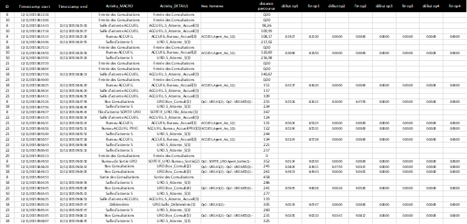

*Extrait du tableau de données de log patient*

## **Devoir 4 — Travail demandé** : Modélisation finale

Ce devoir, réalisé en binôme, est à rendre pour le **14/05/2026** au format Rmd (+ PDF si nécessaire), avec pour titre `NOM_Prenom_FIE5-2-IOS-4-Devoir-4.*`. Il fera l’objet d’une soutenance à cette même date.

L’objectif de ce dernier devoir est de produire une modélisation simulable complète du service d’urologie, articulée en trois étapes :

1. Modélisation des parcours patient par *Process Mining*
2. Simulation du service d’accueil sous AnyLogic
3. Simulation globale du service d’urologie

### Question 1) Modélisation des parcours patient par *Process Mining* (/2.5)

L’objectif de cette question est de modéliser les parcours des patients sous la forme d’une **chaîne de Markov**. Nous nous concentrons uniquement sur les étapes impliquant une ressource soignante ou administrative, en excluant les déplacements et les temps d’attente passifs.

Pour illustrer la démarche, prenons l’exemple du patient d’identifiant 10, dont le parcours comporte 9 opérations :

```r
trace_example_final %>%
  filter(!is.na(CURRENT_OPERATION_NUMBER)) %>%
  filter(ID == 10)
```

| ID | TYPE | CURRENT_LOCATION | NEXT_LOCATION | CURRENT_OPERATION_NUMBER | WITH_1 | WITH_2 | DATETIME_BEGIN | DATETIME_END | DISTANCE_PARCOURUE |
| --- | --- | --- | --- | --- | --- | --- | --- | --- | --- |
| 10 | PATIENT | Accueil_General_2 | Accueil_General_2 | 1 | ACCUEIL.Agent_Acc_1(1) | NA | 2015-11-12 08:30:00 | 2015-11-12 08:33:50 | 120.6894 |
| 10 | PATIENT | Uro_Box_2 | Uro_Box_2 | 1 | URO.AS(2) | NA | 2015-11-12 08:38:20 | 2015-11-12 08:39:11 | 244.7995 |
| 10 | PATIENT | Uro_Box_2 | Uro_Box_2 | 2 | URO.MED(3) | NA | 2015-11-12 08:47:59 | 2015-11-12 09:03:42 | 244.7995 |
| 10 | PATIENT | Uro_Examen_1 | Uro_Examen_1 | 1 | URO.IDE(1) | NA | 2015-11-12 09:06:24 | 2015-11-12 09:06:53 | 315.2527 |
| 10 | PATIENT | Uro_Examen_1 | Uro_Examen_1 | 2 | URO.IDE(1) | NA | 2015-11-12 09:06:53 | 2015-11-12 09:19:34 | 315.2527 |
| 10 | PATIENT | Uro_Examen_1 | Uro_Examen_1 | 3 | URO.MED(3) | URO.IDE(1) | 2015-11-12 09:24:23 | 2015-11-12 09:28:49 | 315.2527 |
| 10 | PATIENT | Uro_Examen_1 | Uro_Examen_1 | 4 | URO.IDE(1) | NA | 2015-11-12 09:28:49 | 2015-11-12 09:34:52 | 315.2527 |
| 10 | PATIENT | Uro_Box_3 | Uro_Box_3 | 2 | URO.MED(3) | NA | 2015-11-12 09:37:51 | 2015-11-12 09:53:51 | 371.3143 |
| 10 | PATIENT | Sortie_Bureau_2 | Sortie_Bureau_2 | 1 | SORTIE_URO.Agent_Sortie(1) | NA | 2015-11-12 09:57:21 | 2015-11-12 09:59:02 | 476.0234 |

Afin de simplifier l’analyse, nous regroupons les opérations par **activité macro** et par **type d’acteur**. Pour le patient 10, cela donne les temps “stricts” suivants (sans encore tenir compte des temps morts des acteurs) :

```r
trace_example_final_b <- trace_example_final %>%
  filter(!is.na(CURRENT_OPERATION_NUMBER)) %>%
  filter(ID == 10) %>%
  mutate(ACTIVITY_MACRO = ifelse(str_detect(CURRENT_LOCATION,"Uro_Box"),
                                 "Consultation",NA),
         ACTIVITY_MACRO = ifelse(str_detect(CURRENT_LOCATION,"Uro_Examen"),
                                 "Examen",ACTIVITY_MACRO),
         ACTIVITY_MACRO = ifelse(str_detect(CURRENT_LOCATION,"Accueil"),
                                 "Accueil",ACTIVITY_MACRO),
         ACTIVITY_MACRO = ifelse(str_detect(CURRENT_LOCATION,"Sortie"),
                                 "Sortie",ACTIVITY_MACRO),
         )

trace_example_final_b %>%
  group_by(ACTIVITY_MACRO,WITH_1) %>%
  summarize(time_in_minutes = sum(as.double(DATETIME_END) - as.double(DATETIME_BEGIN)) / 60)
```

| ACTIVITY_MACRO | WITH_1 | time_in_minutes |
| --- | --- | --- |
| Accueil | ACCUEIL.Agent_Acc_1(1) | 3.8362667 |
| Consultation | URO.AS(2) | 0.8474333 |
| Consultation | URO.MED(3) | 31.7223333 |
| Examen | URO.IDE(1) | 19.2160500 |
| Examen | URO.MED(3) | 4.4258667 |
| Sortie | SORTIE_URO.Agent_Sortie(1) | 1.6820500 |

> **Remarque importante** : ces temps bruts ne suffisent pas pour paramétrer correctement notre modèle. Il est nécessaire de calculer l’*Effective Process Time* (EPT) de chaque acteur, en intégrant les temps morts survenus entre deux opérations successives d’un même acteur (cf. Devoir 3).

La méthodologie adoptée pour construire le modèle de Markov est la suivante :

**Étape 1 — Modélisation macro des séquences d’activités**

**Étape 2 — Modélisation des ressources au sein de chaque activité**

Pour chaque activité macro, nous estimons la probabilité qu’un acteur donné intervienne, puis nous modélisons la durée de son intervention par une **loi gamma**, paramétrée séparément pour les patients prioritaires et standard. Le patient 10 mobilise 6 combinaisons activité / acteur distinctes.

**Étape 3 — Validation par comparaison avec un modèle plus détaillé**

Nous comparons notre modèle simplifié (agrégé par activité macro) à un modèle plus granulaire (par salle individuelle), afin d’évaluer le biais introduit par l’agrégation.

#### 1.a — Préparation des données et calcul de l’EPT

```r
library(tidyverse)
library(lubridate)
library(MASS)
library(gridExtra)
select <- dplyr::select

load("local_data/trace_example_final.RData")
df <- trace_example_final

patients <- df %>% filter(TYPE == "PATIENT")

prio_ids <- unique(patients$ID[patients$CURRENT_LOCATION == "Accueil_Prio_1"])
patients <- patients %>%
  mutate(PRIO = ifelse(ID %in% prio_ids, "Prioritaire", "Standard"))

patients <- patients %>%
  mutate(ACTIVITY_MACRO = case_when(
    str_detect(CURRENT_LOCATION, "Uro_Box")            ~ "Consultation",
    str_detect(CURRENT_LOCATION, "Uro_Bureau_Annonce") ~ "Consultation",
    str_detect(CURRENT_LOCATION, "Uro_Bureau_IDE")     ~ "Consultation",
    str_detect(CURRENT_LOCATION, "Uro_Examen")         ~ "Examen",
    str_detect(CURRENT_LOCATION, "Uro_Debimetrie")     ~ "Examen",
    str_detect(CURRENT_LOCATION, "Accueil")            ~ "Accueil",
    str_detect(CURRENT_LOCATION, "Sortie")             ~ "Sortie",
    TRUE ~ NA_character_
  ))

patients <- patients %>%
  mutate(ACTOR_TYPE = case_when(
    str_detect(WITH_1, "ACCUEIL")         ~ "Agent_Accueil",
    str_detect(WITH_1, "SORTIE")          ~ "Agent_Sortie",
    str_detect(WITH_1, "URO.IDE_Annonce") ~ "IDE_Annonce",
    str_detect(WITH_1, "URO.IDE")         ~ "IDE",
    str_detect(WITH_1, "URO.AS")          ~ "AS",
    str_detect(WITH_1, "URO.MED")         ~ "MED",
    TRUE ~ NA_character_
  ))

ops <- patients %>%
  filter(!is.na(CURRENT_OPERATION_NUMBER)) %>%
  mutate(
    DATETIME_BEGIN = as.POSIXct(DATETIME_BEGIN),
    DATETIME_END   = as.POSIXct(DATETIME_END)
  ) %>%
  arrange(WITH_1, DATETIME_BEGIN) %>%
  group_by(WITH_1) %>%
  mutate(
    DATETIME_END_prev = lag(DATETIME_END),
    tdq = if_else(is.na(DATETIME_END_prev),
                  DATETIME_BEGIN,
                  pmax(DATETIME_BEGIN, DATETIME_END_prev)),
    EPT_secs = as.numeric(difftime(DATETIME_END, tdq, units = "secs")),
    EPT_min  = EPT_secs / 60
  ) %>%
  ungroup()

ops %>%
  filter(ID == 10) %>%
  dplyr::select(ACTIVITY_MACRO, WITH_1, ACTOR_TYPE, DATETIME_BEGIN, DATETIME_END, EPT_min)
```

| ACTIVITY_MACRO | WITH_1 | ACTOR_TYPE | DATETIME_BEGIN | DATETIME_END | EPT_min |
| --- | --- | --- | --- | --- | --- |
| Accueil | ACCUEIL.Agent_Acc_1(1) | Agent_Accueil | 2015-11-12 08:30:00 | 2015-11-12 08:33:50 | 3.8362667 |
| Sortie | SORTIE_URO.Agent_Sortie(1) | Agent_Sortie | 2015-11-12 09:57:21 | 2015-11-12 09:59:02 | 1.6820500 |
| Consultation | URO.AS(2) | AS | 2015-11-12 08:38:20 | 2015-11-12 08:39:11 | 0.8474333 |
| Examen | URO.IDE(1) | IDE | 2015-11-12 09:06:24 | 2015-11-12 09:06:53 | 0.4986167 |
| Examen | URO.IDE(1) | IDE | 2015-11-12 09:06:53 | 2015-11-12 09:19:34 | 12.6750833 |
| Examen | URO.IDE(1) | IDE | 2015-11-12 09:28:49 | 2015-11-12 09:34:52 | 6.0423500 |
| Consultation | URO.MED(3) | MED | 2015-11-12 08:47:59 | 2015-11-12 09:03:42 | 15.7144833 |
| Examen | URO.MED(3) | MED | 2015-11-12 09:24:23 | 2015-11-12 09:28:49 | 4.4258667 |
| Consultation | URO.MED(3) | MED | 2015-11-12 09:37:51 | 2015-11-12 09:53:51 | 16.0078500 |

#### 1.b — Construction de la chaîne de Markov macro

```r
etats <- c("Accueil", "Consultation", "Examen", "Sortie")

sequences <- patients %>%
  filter(!is.na(ACTIVITY_MACRO), ACTIVITY_MACRO %in% etats) %>%
  arrange(ID, DATETIME_BEGIN) %>%
  group_by(ID, PRIO) %>%
  mutate(MACRO_prev = lag(ACTIVITY_MACRO)) %>%
  filter(is.na(MACRO_prev) | ACTIVITY_MACRO != MACRO_prev) %>%
  summarise(sequence = list(ACTIVITY_MACRO), .groups = "drop")

seq_freq <- sequences %>%
  mutate(seq_str = sapply(sequence, paste, collapse = " -> ")) %>%
  count(seq_str, sort = TRUE) %>%
  mutate(pct = round(n / sum(n) * 100, 1))

print(seq_freq)
```

```
# A tibble: 9 × 3
  seq_str                                                                                      n   pct
  <chr>                                                                                    <int> <dbl>
1 Accueil -> Consultation -> Sortie                                                           30  44.1
2 Accueil -> Consultation -> Examen -> Consultation -> Sortie                                 15  22.1
3 Accueil -> Examen -> Consultation -> Sortie                                                  7  10.3
4 Accueil -> Consultation -> Examen -> Sortie                                                  5   7.4
5 Accueil -> Consultation -> Examen -> Consultation -> Examen -> Consultation -> Sortie        4   5.9
6 Accueil -> Consultation -> Examen -> Consultation -> Examen -> Sortie                        4   5.9
7 Accueil -> Consultation -> Examen -> Consultation -> Examen -> Consultation -> Examen -…     1   1.5
8 Accueil -> Examen -> Consultation -> Examen -> Sortie                                        1   1.5
9 Accueil -> Examen -> Sortie                                                                  1   1.5
```

```r
trans_count <- matrix(0, 4, 4, dimnames = list(from = etats, to = etats))

for (seq in sequences$sequence) {
  if (length(seq) >= 2) {
    for (i in seq_len(length(seq) - 1)) {
      f <- seq[i]; t <- seq[i + 1]
      if (f %in% etats && t %in% etats)
        trans_count[f, t] <- trans_count[f, t] + 1
    }
  }
}

trans_prob <- trans_count / rowSums(trans_count)
trans_prob[is.nan(trans_prob)] <- 0

cat("=== Matrice de transition — Chaîne de Markov ===\n")
```

```
=== Matrice de transition — Chaîne de Markov ===
```

```r
print(round(trans_prob, 3))
```

```
              to
from           Accueil Consultation Examen Sortie
  Accueil            0        0.868  0.132  0.000
  Consultation       0        0.000  0.417  0.583
  Examen             0        0.755  0.000  0.245
  Sortie             0        0.000  0.000  0.000
```

La séquence dominante est **Accueil → Consultation → Sortie**, représentant 44,1 % des patients. Il s’agit du parcours “simple” pour les patients dont la consultation ne nécessite pas d’examen complémentaire. La deuxième séquence la plus fréquente (**Accueil → Consultation → Examen → Consultation → Sortie**, 22,1 %) correspond au circuit classique d’un patient orienté vers un examen, suivi d’un retour en consultation pour l’interprétation des résultats.

La matrice de transition met en évidence la structure fortement séquentielle du parcours :

- Depuis l’Accueil, la grande majorité des patients se dirigent vers la Consultation (86,8 %), les 13,2 % restants étant orientés directement vers l’Examen.
- Depuis la Consultation, environ 58 % des patients sortent du service, tandis que 42 % sont envoyés en Examen.
- Depuis l’Examen, 75,5 % des patients retournent en Consultation (pour l’interprétation des résultats) et 24,5 % quittent directement le service.

Il n’existe pas de transition de retour vers l’Accueil, ce qui confirme que cet état est un point d’entrée unique. La Sortie est un **état absorbant** : aucun patient ne repart vers une autre activité une fois sorti.

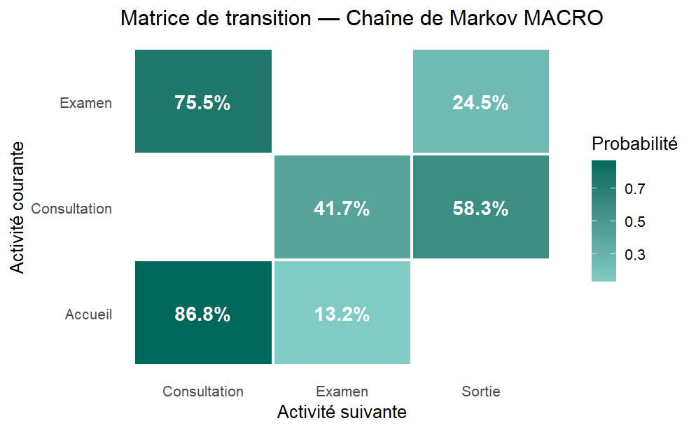

```r
as.data.frame(trans_prob) %>%
  rownames_to_column("De") %>%
  pivot_longer(-De, names_to = "Vers", values_to = "Prob") %>%
  filter(Prob > 0) %>%
  ggplot(aes(x = Vers, y = De, fill = Prob)) +
  geom_tile(color = "white", linewidth = 1) +
  geom_text(aes(label = paste0(round(Prob * 100, 1), "%")),
            color = "white", fontface = "bold", size = 5) +
  scale_fill_gradient(low = "#80CBC4", high = "#00695C") +
  labs(title = "Matrice de transition — Chaîne de Markov MACRO",
       x = "Activité suivante", y = "Activité courante",
       fill = "Probabilité") +
  theme_minimal(base_size = 13) +
  theme(panel.grid = element_blank())
```

La heatmap confirme la lecture de la matrice : les transitions les plus probables (teinte foncée) sont **Accueil → Consultation** et **Examen → Consultation**, ce qui souligne le rôle pivot de la Consultation dans l’organisation du service. L’absence de case colorée sur la ligne “Sortie” confirme bien son caractère absorbant.

#### 1.c — Probabilités de sollicitation des ressources

```r
nb_passages <- sequences %>%
  unnest(sequence) %>%
  rename(ACTIVITY_MACRO = sequence) %>%
  count(PRIO, ACTIVITY_MACRO, name = "nb_passages")

nb_ops <- ops %>%
  filter(!is.na(ACTOR_TYPE)) %>%
  group_by(PRIO, ACTIVITY_MACRO, ACTOR_TYPE, ID) %>%
  summarise(intervient = 1, .groups = "drop") %>%
  group_by(PRIO, ACTIVITY_MACRO, ACTOR_TYPE) %>%
  summarise(nb_ops = n(), .groups = "drop")

proba_res <- nb_ops %>%
  left_join(nb_passages, by = c("PRIO", "ACTIVITY_MACRO")) %>%
  mutate(prob = round(nb_ops / nb_passages, 3))

print(proba_res)
```

```
# A tibble: 20 × 6
   PRIO        ACTIVITY_MACRO ACTOR_TYPE    nb_ops nb_passages   prob
   <chr>       <chr>          <chr>          <int>       <int>  <dbl>
 1 Prioritaire Accueil        Agent_Accueil     19          19  1
 2 Prioritaire Consultation   AS                17          30  0.567
 3 Prioritaire Consultation   IDE                2          30  0.067
 4 Prioritaire Consultation   IDE_Annonce        2          30  0.067
 5 Prioritaire Consultation   MED               17          30  0.567
 6 Prioritaire Examen         AS                 8          16  0.5
 7 Prioritaire Examen         IDE                8          16  0.5
 8 Prioritaire Examen         MED                6          16  0.375
 9 Prioritaire Sortie         Agent_Sortie       6          19  0.316
10 Prioritaire NA             Agent_Sortie       6          NA NA
11 Standard    Accueil        Agent_Accueil     49          49  1
12 Standard    Consultation   AS                37          66  0.561
13 Standard    Consultation   IDE                9          66  0.136
14 Standard    Consultation   IDE_Annonce       12          66  0.182
15 Standard    Consultation   MED               40          66  0.606
16 Standard    Examen         AS                19          33  0.576
17 Standard    Examen         IDE               24          33  0.727
18 Standard    Examen         MED               20          33  0.606
19 Standard    Sortie         Agent_Sortie      12          49  0.245
20 Standard    NA             Agent_Sortie      13          NA NA
```

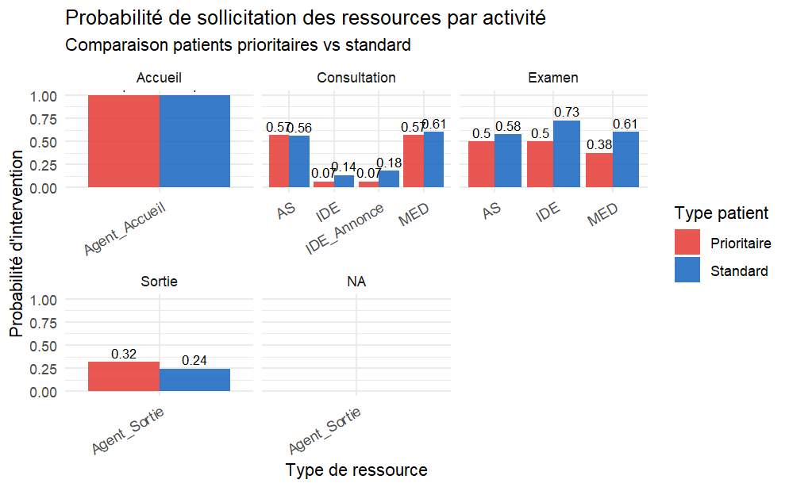

```r
ggplot(proba_res, aes(x = ACTOR_TYPE, y = prob, fill = PRIO)) +
  geom_bar(stat = "identity", position = "dodge", alpha = 0.85) +
  geom_text(aes(label = round(prob, 2)),
            position = position_dodge(0.9), vjust = -0.4, size = 3) +
  facet_wrap(~ ACTIVITY_MACRO, scales = "free_x") +
  scale_fill_manual(values = c("Prioritaire" = "#E53935", "Standard" = "#1565C0")) +
  labs(title = "Probabilité de sollicitation des ressources par activité",
       subtitle = "Comparaison patients prioritaires vs standard",
       x = "Type de ressource", y = "Probabilité d'intervention", fill = "Type patient") +
  theme_minimal() +
  theme(axis.text.x = element_text(angle = 30, hjust = 1))
```

Les probabilités d’intervention révèlent une structure cohérente avec l’organisation du service :

- À l’**Accueil**, l’Agent_Accueil intervient systématiquement (100 % des passages), ce qui est logique puisqu’il s’agit du point d’entrée obligatoire.
- En **Consultation**, le MED est sollicité dans 57 à 61 % des passages, l’AS dans 56 à 57 % des cas. L’IDE et l’IDE_Annonce interviennent plus rarement (7 à 18 %), réservés à des actes spécifiques (soins infirmiers, annonces de diagnostic).
- Les taux d’intervention sont proches entre patients prioritaires et standards en Consultation, ce qui suggère que la priorité influe davantage sur *l’ordre de passage* que sur la *nature des actes* réalisés.
- En **Examen**, l’IDE est la ressource la plus mobilisée (50 à 73 % des passages), devant l’AS (50 à 58 %) et le MED (38 à 61 %). La variabilité plus marquée chez les patients prioritaires s’explique probablement par le faible effectif de ce sous-groupe dans cette activité (n ≈ 10), rendant les estimations moins robustes.

#### 1.d — Ajustement des durées de service par une loi Gamma

```r
ops_valid <- ops %>%
  filter(!is.na(ACTOR_TYPE), !is.na(EPT_min), EPT_min > 0)

combos <- ops_valid %>%
  group_by(ACTIVITY_MACRO, ACTOR_TYPE, PRIO) %>%
  summarise(n = n(), .groups = "drop") %>%
  filter(n >= 5)

resultats_gamma <- data.frame()

for (i in seq_len(nrow(combos))) {
  m <- combos$ACTIVITY_MACRO[i]
  a <- combos$ACTOR_TYPE[i]
  p <- combos$PRIO[i]

  x <- ops_valid$EPT_min[
    ops_valid$ACTIVITY_MACRO == m &
    ops_valid$ACTOR_TYPE == a &
    ops_valid$PRIO == p
  ]

  fit <- tryCatch(fitdistr(x, "gamma"), error = function(e) NULL)

  if (!is.null(fit)) {
    sh <- fit$estimate["shape"]
    ra <- fit$estimate["rate"]
    resultats_gamma <- bind_rows(resultats_gamma, data.frame(
      PRIO = p, ACTIVITY_MACRO = m, ACTOR_TYPE = a,
      n = length(x),
      shape = round(sh, 3),
      rate  = round(ra, 3),
      mean_EPT_min = round(sh / ra, 2),
      cv = round(1 / sqrt(sh), 3)
    ))
  }
}

print(resultats_gamma)
```

```
                  PRIO ACTIVITY_MACRO    ACTOR_TYPE  n  shape   rate mean_EPT_min    cv
shape...1  Prioritaire        Accueil Agent_Accueil 19 24.141  6.109         3.95 0.204
shape...2     Standard        Accueil Agent_Accueil 49 23.699  5.946         3.99 0.205
shape...3  Prioritaire   Consultation            AS 19  8.673 13.253         0.65 0.340
shape...4     Standard   Consultation            AS 38 11.977 19.266         0.62 0.289
shape...5     Standard   Consultation           IDE  9 19.527  2.974         6.57 0.226
shape...6     Standard   Consultation   IDE_Annonce 12 13.107  0.340        38.54 0.276
shape...7  Prioritaire   Consultation           MED 27  1.907  0.145        13.16 0.724
shape...8     Standard   Consultation           MED 59  1.793  0.131        13.72 0.747
shape...9  Prioritaire         Examen            AS 10  3.642  2.938         1.24 0.524
shape...10    Standard         Examen            AS 22  2.448  2.133         1.15 0.639
shape...11 Prioritaire         Examen           IDE 19  1.918  0.224         8.58 0.722
shape...12    Standard         Examen           IDE 51  1.808  0.240         7.53 0.744
shape...13 Prioritaire         Examen           MED  6  8.606  1.903         4.52 0.341
shape...14    Standard         Examen           MED 20 15.504  2.639         5.87 0.254
```

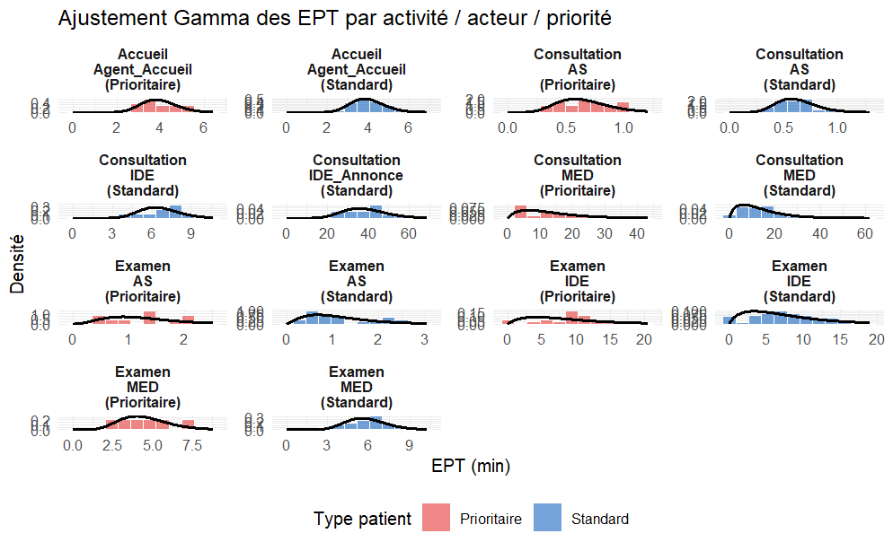

```r
# Construire un dataframe avec les données observées + courbe gamma pour chaque combo
plot_data <- purrr::map_dfr(seq_len(nrow(resultats_gamma)), function(i) {
  row <- resultats_gamma[i, ]
  x <- ops_valid$EPT_min[
    ops_valid$ACTIVITY_MACRO == row$ACTIVITY_MACRO &
    ops_valid$ACTOR_TYPE == row$ACTOR_TYPE &
    ops_valid$PRIO == row$PRIO
  ]
  data.frame(
    EPT_min = x,
    facet_label = paste0(row$ACTIVITY_MACRO, "\n", row$ACTOR_TYPE, "\n(", row$PRIO, ")"),
    PRIO = row$PRIO
  )
})

curve_data <- purrr::map_dfr(seq_len(nrow(resultats_gamma)), function(i) {
  row <- resultats_gamma[i, ]
  x <- ops_valid$EPT_min[
    ops_valid$ACTIVITY_MACRO == row$ACTIVITY_MACRO &
    ops_valid$ACTOR_TYPE == row$ACTOR_TYPE &
    ops_valid$PRIO == row$PRIO
  ]
  x_seq <- seq(0, max(x) * 1.2, length.out = 300)
  data.frame(
    x = x_seq,
    y = dgamma(x_seq, shape = row$shape, rate = row$rate),
    facet_label = paste0(row$ACTIVITY_MACRO, "\n", row$ACTOR_TYPE, "\n(", row$PRIO, ")")
  )
})

ggplot(plot_data, aes(x = EPT_min)) +
  geom_histogram(aes(y = after_stat(density), fill = PRIO),
                 bins = 12, alpha = 0.6, color = "white") +
  geom_line(data = curve_data, aes(x = x, y = y), color = "black", linewidth = 0.8) +
  scale_fill_manual(values = c("Prioritaire" = "#E53935", "Standard" = "#1565C0")) +
  facet_wrap(~ facet_label, scales = "free", ncol = 4) +
  labs(title = "Ajustement Gamma des EPT par activité / acteur / priorité",
       x = "EPT (min)", y = "Densité", fill = "Type patient") +
  theme_minimal(base_size = 10) +
  theme(strip.text = element_text(size = 8, face = "bold"),
        legend.position = "bottom")
```

#### 1.e — Validation du modèle par simulation Monte Carlo

```r
set.seed(42)
N_sim <- 1000

sim_parcours <- function() {
  etat <- "Accueil"
  parcours <- etat
  while (etat != "Sortie" && length(parcours) < 8) {
    probs <- trans_prob[etat, ]
    if (sum(probs) == 0) break
    etat <- sample(etats, 1, prob = probs)
    parcours <- c(parcours, etat)
  }
  paste(parcours, collapse = " -> ")
}

sim_seqs <- replicate(N_sim, sim_parcours())
sim_table <- as.data.frame(table(sim_seqs)) %>%
  rename(seq_str = sim_seqs, n_sim = Freq) %>%
  mutate(pct_sim = round(n_sim / N_sim * 100, 1))

obs_table <- sequences %>%
  mutate(seq_str = sapply(sequence, paste, collapse = " -> ")) %>%
  count(seq_str) %>%
  mutate(pct_obs = round(n / sum(n) * 100, 1))

comparison <- obs_table %>%
  left_join(sim_table, by = "seq_str") %>%
  replace_na(list(n_sim = 0, pct_sim = 0)) %>%
  arrange(desc(pct_obs)) %>%
  mutate(seq_label = ifelse(nchar(seq_str) > 50,
                            paste0(substr(seq_str, 1, 47), "..."),
                            seq_str))

print(comparison %>% dplyr::select(seq_str, pct_obs, pct_sim))
```

```
# A tibble: 9 × 3
  seq_str                                                                              pct_obs pct_sim
  <chr>                                                                                  <dbl>   <dbl>
1 Accueil -> Consultation -> Sortie                                                       44.1    50.9
2 Accueil -> Consultation -> Examen -> Consultation -> Sortie                             22.1    16.5
3 Accueil -> Examen -> Consultation -> Sortie                                             10.3     5.3
4 Accueil -> Consultation -> Examen -> Sortie                                              7.4     8.8
5 Accueil -> Consultation -> Examen -> Consultation -> Examen -> Consultation -> Sort…     5.9     4.5
6 Accueil -> Consultation -> Examen -> Consultation -> Examen -> Sortie                    5.9     2.9
7 Accueil -> Consultation -> Examen -> Consultation -> Examen -> Consultation -> Exam…     1.5     1
8 Accueil -> Examen -> Consultation -> Examen -> Sortie                                    1.5     1
9 Accueil -> Examen -> Sortie                                                              1.5     3.3
```

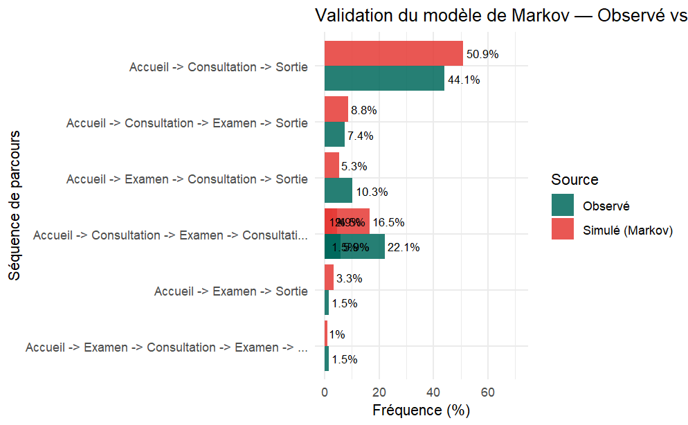

```r
comparison %>%
  pivot_longer(cols = c(pct_obs, pct_sim), names_to = "Source", values_to = "Pct") %>%
  mutate(Source = ifelse(Source == "pct_obs", "Observé", "Simulé (Markov)")) %>%
  ggplot(aes(x = reorder(seq_label, Pct), y = Pct, fill = Source)) +
  geom_bar(stat = "identity", position = "dodge", alpha = 0.85) +
  geom_text(aes(label = paste0(Pct, "%")),
            position = position_dodge(0.9), hjust = -0.1, size = 3) +
  coord_flip() +
  scale_fill_manual(values = c("Observé" = "#00695C", "Simulé (Markov)" = "#E53935")) +
  labs(title = "Validation du modèle de Markov — Observé vs Simulé (N = 1 000)",
       x = "Séquence de parcours", y = "Fréquence (%)") +
  theme_minimal() +
  expand_limits(y = max(comparison$pct_obs, comparison$pct_sim, na.rm = TRUE) * 1.4)
```

La simulation Monte Carlo sur 1 000 patients virtuels montre que le modèle de Markov reproduit de manière satisfaisante les distributions observées.

La séquence **Accueil → Consultation → Sortie** est légèrement sur-estimée par le modèle (50,9 % simulé vs 44,1 % observé), tandis que le circuit avec aller-retour en Examen (**Accueil → Consultation → Examen → Consultation → Sortie**) est légèrement sous-estimé (16,5 % vs 22,1 %). Cet écart est inhérent à l’hypothèse de Markov : chaque transition est supposée indépendante de l’historique du patient, ce qui ne permet pas de capter les corrélations entre étapes successives (par exemple, un patient ayant eu un examen a peut-être une probabilité plus élevée de retourner en consultation qu’un patient n’en ayant pas eu).

Malgré ces limites, les ordres de grandeur sont bien respectés et le modèle constitue une base robuste pour paramétrer la simulation AnyLogic de la Question 3.

#### 1.f — Comparaison avec un modèle plus détaillé

```r
ops_detail <- ops %>%
  filter(!is.na(ACTOR_TYPE), !is.na(EPT_min), EPT_min > 0)

combos_detail <- ops_detail %>%
  group_by(CURRENT_LOCATION, ACTOR_TYPE, PRIO) %>%
  summarise(n = n(), .groups = "drop") %>%
  filter(n >= 5)

resultats_detail <- data.frame()

for (i in seq_len(nrow(combos_detail))) {
  loc <- combos_detail$CURRENT_LOCATION[i]
  a   <- combos_detail$ACTOR_TYPE[i]
  p   <- combos_detail$PRIO[i]

  x <- ops_detail$EPT_min[
    ops_detail$CURRENT_LOCATION == loc &
    ops_detail$ACTOR_TYPE == a &
    ops_detail$PRIO == p
  ]

  fit <- tryCatch(fitdistr(x, "gamma"), error = function(e) NULL)

  if (!is.null(fit)) {
    sh <- fit$estimate["shape"]
    ra <- fit$estimate["rate"]
    resultats_detail <- bind_rows(resultats_detail, data.frame(
      PRIO = p, CURRENT_LOCATION = loc, ACTOR_TYPE = a,
      n = length(x),
      shape = round(sh, 3),
      rate  = round(ra, 3),
      mean_EPT_min = round(sh / ra, 2),
      cv = round(1 / sqrt(sh), 3)
    ))
  }
}

print(resultats_detail)
```

```
                  PRIO     CURRENT_LOCATION    ACTOR_TYPE  n  shape   rate mean_EPT_min    cv
shape...1     Standard    Accueil_General_1 Agent_Accueil 16 36.852 10.111         3.64 0.165
shape...2     Standard    Accueil_General_2 Agent_Accueil 14 20.845  5.168         4.03 0.219
shape...3     Standard    Accueil_General_3 Agent_Accueil 19 24.838  5.862         4.24 0.201
shape...4  Prioritaire       Accueil_Prio_1 Agent_Accueil 19 24.141  6.109         3.95 0.204
shape...5     Standard            Uro_Box_1            AS  6 12.980 22.348         0.58 0.278
shape...6     Standard            Uro_Box_1           MED  8  2.512  0.110        22.79 0.631
shape...7     Standard            Uro_Box_2            AS  6 13.777 24.723         0.56 0.269
shape...8     Standard            Uro_Box_2           MED 10  3.161  0.271        11.67 0.562
shape...9     Standard            Uro_Box_3            AS  8 19.521 30.107         0.65 0.226
shape...10    Standard            Uro_Box_3           MED 10  1.972  0.160        12.34 0.712
shape...11    Standard            Uro_Box_4            AS  5 44.391 82.852         0.54 0.150
shape...12 Prioritaire            Uro_Box_4           MED  5  1.875  0.185        10.11 0.730
shape...13    Standard            Uro_Box_4           MED  7  6.431  0.399        16.12 0.394
shape...14 Prioritaire            Uro_Box_5           MED  5  2.003  0.185        10.82 0.707
shape...15    Standard            Uro_Box_5           MED  8  1.163  0.081        14.43 0.927
shape...16    Standard            Uro_Box_6            AS  5  8.382 11.790         0.71 0.345
shape...17    Standard            Uro_Box_6           MED  8  2.025  0.208         9.72 0.703
shape...18    Standard            Uro_Box_7           MED  8  1.495  0.148        10.11 0.818
shape...19    Standard Uro_Bureau_Annonce_1   IDE_Annonce 12 13.107  0.340        38.54 0.276
shape...20    Standard     Uro_Bureau_IDE_1           IDE  9 19.527  2.974         6.57 0.226
shape...21 Prioritaire     Uro_Debimetrie_1            AS  6 24.358 14.522         1.68 0.203
shape...22    Standard     Uro_Debimetrie_1            AS  8 18.983  9.349         2.03 0.230
shape...23    Standard         Uro_Examen_1            AS  7  4.717  7.294         0.65 0.460
shape...24    Standard         Uro_Examen_1           IDE 25  2.064  0.291         7.09 0.696
shape...25    Standard         Uro_Examen_1           MED 10 35.026  5.785         6.05 0.169
shape...26 Prioritaire         Uro_Examen_2           IDE  9  1.819  0.251         7.25 0.742
shape...27    Standard         Uro_Examen_2           IDE 10  2.282  0.306         7.45 0.662
shape...28 Prioritaire         Uro_Examen_3           IDE  6  1.638  0.211         7.76 0.781
shape...29    Standard         Uro_Examen_3           IDE 16  1.399  0.169         8.26 0.845
shape...30    Standard         Uro_Examen_3           MED  6 12.389  2.217         5.59 0.284
```

```r
resultats_detail <- resultats_detail %>%
  mutate(ACTIVITY_MACRO = case_when(
    str_detect(CURRENT_LOCATION, "Uro_Box")            ~ "Consultation",
    str_detect(CURRENT_LOCATION, "Uro_Bureau_Annonce") ~ "Consultation",
    str_detect(CURRENT_LOCATION, "Uro_Bureau_IDE")     ~ "Consultation",
    str_detect(CURRENT_LOCATION, "Uro_Examen")         ~ "Examen",
    str_detect(CURRENT_LOCATION, "Uro_Debimetrie")     ~ "Examen",
    str_detect(CURRENT_LOCATION, "Accueil")            ~ "Accueil",
    str_detect(CURRENT_LOCATION, "Sortie")             ~ "Sortie",
    TRUE ~ NA_character_
  ))

comp_modeles <- resultats_gamma %>%
  dplyr::select(PRIO, ACTIVITY_MACRO, ACTOR_TYPE,
                mean_simple = mean_EPT_min, cv_simple = cv) %>%
  left_join(
    resultats_detail %>%
      group_by(PRIO, ACTIVITY_MACRO, ACTOR_TYPE) %>%
      summarise(
        mean_detail = round(weighted.mean(mean_EPT_min, n), 2),
        cv_detail   = round(mean(cv), 3),
        .groups = "drop"
      ),
    by = c("PRIO", "ACTIVITY_MACRO", "ACTOR_TYPE")
  ) %>%
  mutate(diff_mean_pct = round((mean_detail - mean_simple) / mean_simple * 100, 1))

cat("=== Comparaison modèle simplifié vs modèle détaillé ===\n")
```

```
=== Comparaison modèle simplifié vs modèle détaillé ===
```

```r
print(comp_modeles)
```

```
          PRIO ACTIVITY_MACRO    ACTOR_TYPE mean_simple cv_simple mean_detail cv_detail diff_mean_pct
1  Prioritaire        Accueil Agent_Accueil        3.95     0.204        3.95     0.204           0.0
2     Standard        Accueil Agent_Accueil        3.99     0.205        3.98     0.195          -0.3
3  Prioritaire   Consultation            AS        0.65     0.340          NA        NA            NA
4     Standard   Consultation            AS        0.62     0.289        0.61     0.254          -1.6
5     Standard   Consultation           IDE        6.57     0.226        6.57     0.226           0.0
6     Standard   Consultation   IDE_Annonce       38.54     0.276       38.54     0.276           0.0
7  Prioritaire   Consultation           MED       13.16     0.724       10.46     0.718         -20.5
8     Standard   Consultation           MED       13.72     0.747       13.72     0.678           0.0
9  Prioritaire         Examen            AS        1.24     0.524        1.68     0.203          35.5
10    Standard         Examen            AS        1.15     0.639        1.39     0.345          20.9
11 Prioritaire         Examen           IDE        8.58     0.722        7.45     0.762         -13.2
12    Standard         Examen           IDE        7.53     0.744        7.53     0.734           0.0
13 Prioritaire         Examen           MED        4.52     0.341          NA        NA            NA
14    Standard         Examen           MED        5.87     0.254        5.88     0.226           0.2
```

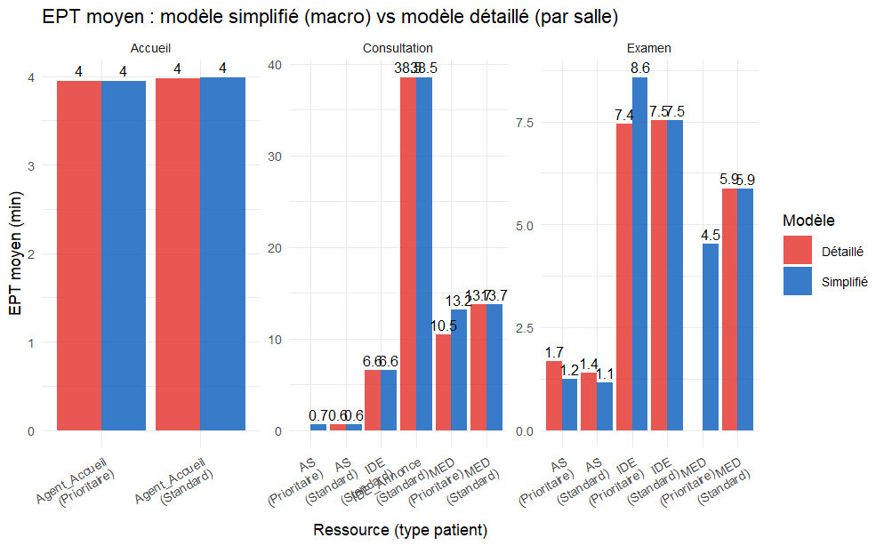

```r
comp_modeles %>%
  pivot_longer(cols = c(mean_simple, mean_detail),
               names_to = "Modele", values_to = "mean_EPT") %>%
  mutate(
    Modele = ifelse(Modele == "mean_simple", "Simplifié", "Détaillé"),
    label  = paste0(ACTOR_TYPE, "\n(", PRIO, ")")
  ) %>%
  ggplot(aes(x = label, y = mean_EPT, fill = Modele)) +
  geom_bar(stat = "identity", position = "dodge", alpha = 0.85) +
  geom_text(aes(label = round(mean_EPT, 1)),
            position = position_dodge(0.9), vjust = -0.4, size = 2.8) +
  facet_wrap(~ ACTIVITY_MACRO, scales = "free") +
  scale_fill_manual(values = c("Simplifié" = "#1565C0", "Détaillé" = "#E53935")) +
  labs(title = "EPT moyen : modèle simplifié (macro) vs modèle détaillé (par salle)",
       x = "Ressource (type patient)", y = "EPT moyen (min)", fill = "Modèle") +
  theme_minimal(base_size = 9) +
  theme(axis.text.x = element_text(angle = 30, hjust = 1))
```

La confrontation entre le modèle agrégé (par activité macro) et le modèle détaillé (par salle individuelle) montre que les deux approches donnent des résultats très proches pour la majorité des combinaisons, avec des écarts inférieurs à 5 %.

**Conclusion** : le modèle simplifié offre un bon compromis entre fidélité à la réalité et complexité de mise en œuvre. Son utilisation pour paramétrer la simulation AnyLogic de la Question 3 est justifiée, à condition de garder en tête les biais identifiés pour les ressources MED Prioritaire et AS Examen Standard.

### Question 2) Simulation du service d’accueil sous AnyLogic (/2.5)

À l’aide d’AnyLogic, construisez le modèle de simulation du service d’accueil correspondant aux résultats du Devoir 3, avec un modèle à **1 serveur** pour le bureau prioritaire et un modèle à **3 serveurs** pour les autres.

Vous testerez différentes combinaisons de scénarios :

- Arrivées réelles, puis arrivées de Poisson homogènes, puis arrivées de Poisson non homogènes
- Temps de service exponentiels, puis loi Gamma

Pour les scénarios avec arrivées de Poisson (homogènes et non homogènes), étudiez l’évolution du taux d’occupation et de l’attente en fonction du taux λ d’arrivée, et vérifiez que la saturation du service survient lorsque le taux d’arrivée atteint le taux de service maximal (ρ ≥ 1).

Enfin, à partir des arrivées réelles, testez le comportement du modèle pour différents nombres de serveurs avec un planning **dynamique** sur les tranches [8h ; 14h] et [14h ; 20h], avec 1 à 4 agents d’accueil disponibles par tranche (les patients prioritaires/non prioritaires peuvent être redirigés vers un autre bureau si nécessaire).

```r
# Charger les données accueil
accueil <- devoir3_data_accueil

library(dplyr)
library(lubridate)
library(writexl)

# Date de référence de la journée simulée
date_debut <- as.POSIXct("2015-11-12 08:00:00", tz = "Europe/Paris")

# Extraire les arrivées réelles à l'accueil
arrivees <- patients %>%
  filter(ACTIVITY_MACRO == "Accueil") %>%
  group_by(ID, PRIO) %>%
  summarise(
    date_arrivee = min(as.POSIXct(DATETIME_BEGIN, tz = "Europe/Paris")),
    .groups = "drop"
  ) %>%
  arrange(date_arrivee) %>%
  mutate(
    id = row_number(),
    prio = PRIO,
    minutes_depuis_8h = as.numeric(difftime(date_arrivee, date_debut, units = "mins"))
  ) %>%
  select(id, ID, prio, date_arrivee, minutes_depuis_8h)

# Export Excel pour AnyLogic
write_xlsx(arrivees, "local_data/arrivees_accueil.xlsx")

# Export CSV au cas où
write.csv2(arrivees, "local_data/arrivees_accueil.csv", row.names = FALSE)

# Exporter aussi les paramètres gamma de l'accueil
params_accueil <- resultats_gamma %>%
  filter(ACTIVITY_MACRO == "Accueil")

write.csv2(params_accueil, "local_data/params_gamma_accueil.csv", row.names = FALSE)

print(arrivees)
```

```
# A tibble: 68 × 5
      id ID    prio        date_arrivee        minutes_depuis_8h
   <int> <chr> <chr>       <dttm>                          <dbl>
 1     1 8     Standard    2015-11-12 09:14:42              74.7
 2     2 10    Standard    2015-11-12 09:17:17              77.3
 3     3 18    Standard    2015-11-12 09:27:26              87.4
 4     4 21    Standard    2015-11-12 09:39:34              99.6
 5     5 22    Standard    2015-11-12 09:42:15             102.
 6     6 23    Prioritaire 2015-11-12 09:44:11             104.
 7     7 29    Standard    2015-11-12 10:06:24             126.
 8     8 39    Standard    2015-11-12 10:20:25             140.
 9     9 43    Standard    2015-11-12 10:24:15             144.
10    10 48    Prioritaire 2015-11-12 10:32:26             152.
# ℹ 58 more rows
# ℹ Use `print(n = ...)` to see more rows
```

```r
print(params_accueil)
```

```
                 PRIO ACTIVITY_MACRO    ACTOR_TYPE  n  shape  rate mean_EPT_min    cv
shape...1 Prioritaire        Accueil Agent_Accueil 19 24.141 6.109         3.95 0.204
shape...2    Standard        Accueil Agent_Accueil 49 23.699 5.946         3.99 0.205
```

Simulation sous Anylogic :

Scénario A - Fonction exponentielle et capacité prio 1 / standard 3

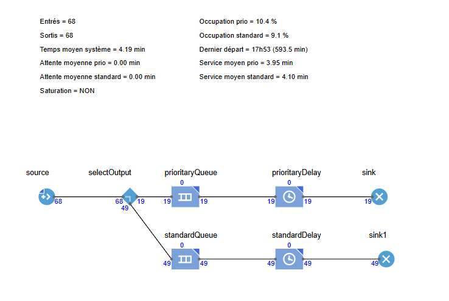

Le scénario A correspond à la configuration de référence, avec les arrivées réelles, une loi de service exponentielle, un agent prioritaire et trois agents standards. Les 68 patients observés dans les données sont bien générés et sortent tous du système. Le dernier départ a lieu à 17h53, donc avant la limite de 20h. Le système n’est donc pas saturé.

Le temps moyen dans le système est de 4,19 minutes, ce qui est cohérent avec les temps de service moyens simulés : 3,95 minutes pour les patients prioritaires et 4,10 minutes pour les patients standards. Les attentes moyennes sont nulles, ce qui montre que la capacité d’accueil est suffisante dans cette configuration.

Les taux d’occupation restent faibles, avec 10,4 % pour l’agent prioritaire et 9,1 % pour les agents standards. Cette configuration est donc confortable par rapport au flux réel observé.

Scénario B - Fonction exponentielle et capacité prio 1 / standard 2

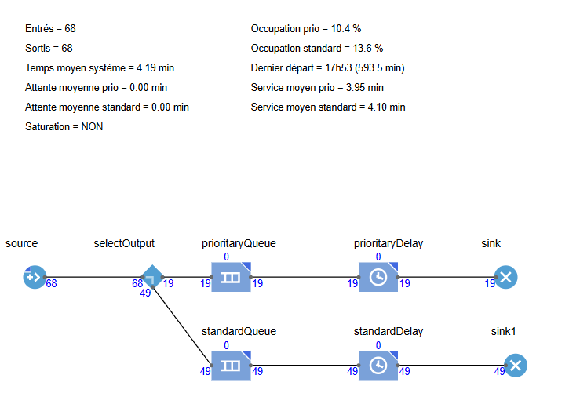

Le scénario B reprend les arrivées réelles et les temps de service exponentiels du scénario de référence, mais réduit le nombre d’agents standards de trois à deux. Malgré cette réduction de capacité, les 68 patients sont pris en charge et sortent tous du système. Le dernier départ reste à 17h53, donc avant 20h, et le système n’est pas saturé.

Le temps moyen dans le système reste identique au scénario A, avec 4,19 minutes. Les attentes moyennes restent nulles pour les patients prioritaires et standards. La principale différence concerne le taux d’occupation des agents standards, qui passe de 9,1 % à 13,6 %. Cette augmentation est logique : la même charge de travail est répartie sur moins d’agents standards.

Ce scénario montre que la capacité standard peut être réduite de trois à deux agents sans dégrader les performances du système dans les conditions observées.

Scénario C - Fonction exponentielle et capacité prio 1 / standard 1

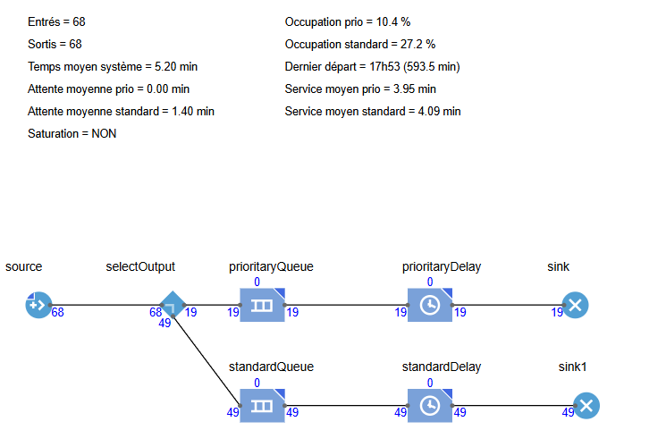

Le scénario C réduit la capacité standard à un seul agent, tout en conservant un agent prioritaire. Les 68 patients sont toujours pris en charge et sortent tous du système. Le dernier départ reste à 17h53, donc avant la limite de 20h. Le système n’est donc pas saturé.

Cependant, contrairement aux scénarios A et B, l’attente moyenne des patients standards devient positive et atteint 1,40 minute. Le temps moyen dans le système augmente également, passant de 4,19 minutes dans les scénarios A et B à 5,20 minutes. Cette hausse est cohérente avec la réduction de capacité : les patients standards doivent plus souvent attendre qu’un agent soit disponible.

Le taux d’occupation standard augmente fortement, passant de 9,1 % dans le scénario A à 27,2 % dans le scénario C. Malgré cette augmentation, le niveau d’occupation reste inférieur à 100 %, ce qui explique l’absence de saturation. Cette configuration est donc encore acceptable, mais elle est moins confortable que les scénarios A et B.

Scénario D - Fonction poisson homogene cap prio 1 et standard 3

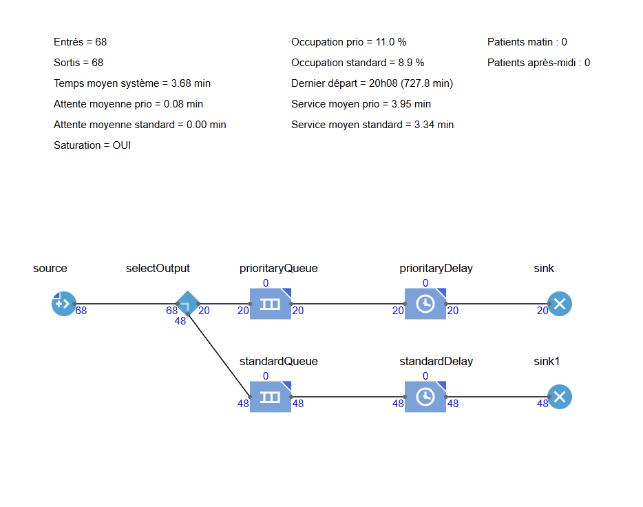

Le scénario D remplace les arrivées réelles par un processus de Poisson homogène. Dans ce scénario, les arrivées sont générées aléatoirement avec un taux moyen constant sur l’ensemble de la journée. Le volume total de patients est conservé, avec 68 patients entrés et 68 patients sortis.

Le temps moyen dans le système est de 3,68 minutes, ce qui est légèrement inférieur au scénario de référence. Cette différence s’explique notamment par un temps de service standard simulé plus faible dans ce run, égal à 3,34 minutes. Les attentes moyennes restent très faibles : 0,08 minute pour les patients prioritaires et 0,00 minute pour les patients standards. Les taux d’occupation restent également faibles, avec 11,0 % pour l’agent prioritaire et 8,9 % pour les agents standards.

Cependant, le dernier départ a lieu à 20h08, soit après la limite fixée à 20h. Même si tous les patients sont bien sortis du système, la contrainte horaire n’est pas respectée. Le scénario D est donc considéré comme saturé.

Ce résultat montre que l’hypothèse d’un processus de Poisson homogène peut produire une répartition temporelle des arrivées moins favorable que les arrivées réelles. Même avec le même nombre total de patients, l’aléatoire peut générer des arrivées plus tardives, ce qui repousse le dernier départ après 20h.

Scénario E - Fonction poisson non homogène

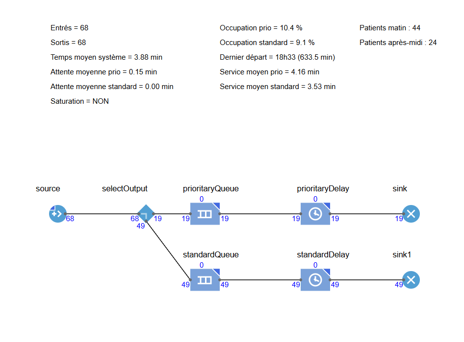

Le scénario E utilise un processus de Poisson non homogène pour générer les arrivées. Contrairement au scénario D, le taux d’arrivée n’est pas constant sur toute la journée : il varie selon la période, avec une distinction entre les arrivées du matin et celles de l’après-midi.

Le modèle génère 68 patients au total, dont 44 patients le matin et 24 patients l’après-midi. Tous les patients sont pris en charge et sortent du système. Le dernier départ a lieu à 18h33, donc avant la limite de 20h. Le système n’est donc pas saturé.

Le temps moyen dans le système est de 3,88 minutes, avec une attente moyenne très faible : 0,15 minute pour les patients prioritaires et 0,00 minute pour les patients standards. Les taux d’occupation restent également faibles, avec 10,4 % pour l’agent prioritaire et 9,1 % pour les agents standards.

Ce scénario montre que le modèle de Poisson non homogène reproduit mieux la dynamique des arrivées qu’un Poisson homogène. En tenant compte d’une intensité d’arrivée différente selon la période de la journée, le dernier départ reste avant 20h, contrairement au scénario D.

Scénario F - Service gamma

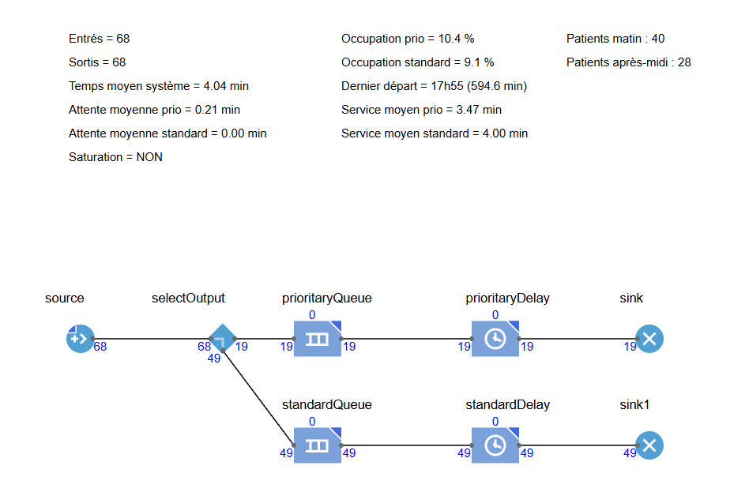

Le scénario F conserve les arrivées réelles et la configuration de capacité du scénario de référence, avec un agent prioritaire et trois agents standards. La différence principale porte sur la loi de service : les temps de service sont modélisés par une loi Gamma au lieu d’une loi exponentielle.

Les 68 patients sont bien générés et sortent tous du système. Le dernier départ a lieu à 17h55, donc avant la limite de 20h. Le système n’est donc pas saturé.

Le temps moyen dans le système est de 4,04 minutes, ce qui est très proche du scénario A, où il était de 4,19 minutes. L’attente moyenne reste très faible : 0,21 minute pour les patients prioritaires et 0,00 minute pour les patients standards. Les taux d’occupation sont identiques au scénario A, avec 10,4 % pour l’agent prioritaire et 9,1 % pour les agents standards.

Le passage d’une loi exponentielle à une loi Gamma ne modifie donc pas fortement les performances globales du système dans cette configuration. Cela s’explique par le fait que le système est peu chargé : les agents sont disponibles la majorité du temps, donc la variabilité des temps de service a peu d’impact sur les files d’attente.

### Discussion supplémentaire (Question 2)

```r
# ============================================================
# Comparaison des scénarios avec la réalité observée
# ============================================================

library(dplyr)
library(knitr)

resultats_q2 <- data.frame(
  Scenario = c("A", "B", "C", "D", "E", "F"),
  Description = c(
    "Réel + exponentiel + capacité 1/3",
    "Réel + exponentiel + capacité 1/2",
    "Réel + exponentiel + capacité 1/1",
    "Poisson homogène + exponentiel + capacité 1/3",
    "Poisson non homogène + exponentiel + capacité 1/3",
    "Réel + Gamma + capacité 1/3"
  ),
  Entres = c(68, 68, 68, 68, 68, 68),
  Sortis = c(68, 68, 68, 68, 68, 68),
  Temps_systeme_min = c(4.19, 4.19, 5.20, 3.68, 3.88, 4.04),
  Attente_prio_min = c(0.00, 0.00, 0.00, 0.08, 0.15, 0.21),
  Attente_standard_min = c(0.00, 0.00, 1.40, 0.00, 0.00, 0.00),
  Occupation_prio_pct = c(10.4, 10.4, 10.4, 11.0, 10.4, 10.4),
  Occupation_standard_pct = c(9.1, 13.6, 27.2, 8.9, 9.1, 9.1),
  Dernier_depart_min = c(593.5, 593.5, 593.5, 727.8, 633.5, 594.6),
  Dernier_depart_h = c("17h53", "17h53", "17h53", "20h08", "18h33", "17h55"),
  Saturation = c("NON", "NON", "NON", "OUI", "NON", "NON")
)

# Le scénario A est utilisé comme scénario de référence, car il utilise les arrivées réelles.
reference <- resultats_q2 %>%
  filter(Scenario == "A")

comparaison_q2 <- resultats_q2 %>%
  mutate(
    Ecart_temps_systeme_min = round(Temps_systeme_min - reference$Temps_systeme_min, 2),
    Ecart_attente_standard_min = round(Attente_standard_min - reference$Attente_standard_min, 2),
    Ecart_occupation_standard_points = round(Occupation_standard_pct - reference$Occupation_standard_pct, 1),
    Ecart_dernier_depart_min = round(Dernier_depart_min - reference$Dernier_depart_min, 1)
  )

kable(
  comparaison_q2,
  caption = "Comparaison des scénarios simulés avec le scénario de référence observé"
)
```

[output not shown]

Afin de répondre à la consigne complémentaire, les résultats des scénarios simulés ont été comparés à la réalité observée dans les données. Pour la question 2, le scénario A est utilisé comme scénario de référence, car il utilise les arrivées réelles observées dans la base de données. Il reproduit donc directement le volume réel de patients, soit 68 patients au total, dont 19 patients prioritaires et 49 patients standards.

Dans le scénario A, les 68 patients entrent et sortent du système. Le dernier départ a lieu à 17h53, donc avant la limite de 20h. Le temps moyen dans le système est de 4,19 minutes, avec une attente moyenne nulle pour les patients prioritaires et standards. Ce scénario est donc cohérent avec la situation observée : l’accueil n’est pas saturé dans la configuration de référence.

Les scénarios B et C permettent de comparer l’effet d’une réduction de capacité par rapport à cette situation réelle. Dans le scénario B, le nombre d’agents standards est réduit de trois à deux. Les résultats restent identiques au scénario A pour le temps moyen système et le dernier départ. En revanche, le taux d’occupation standard augmente de 9,1 % à 13,6 %, soit une hausse de 4,5 points. Cela montre que la même charge est répartie sur moins d’agents, sans toutefois créer d’attente supplémentaire.

Dans le scénario C, la capacité standard est réduite à un seul agent. Le temps moyen dans le système passe de 4,19 minutes à 5,20 minutes, soit une hausse de 1,01 minute. L’attente moyenne standard passe de 0,00 à 1,40 minute. Le taux d’occupation standard augmente fortement, passant de 9,1 % à 27,2 %, soit une hausse de 18,1 points. Malgré cela, le dernier départ reste à 17h53 et le système n’est pas saturé. Ce scénario montre donc que la réduction de capacité dégrade la qualité de service, même si elle ne provoque pas encore de saturation.

Les scénarios D et E permettent d’étudier l’effet du modèle d’arrivée. Le scénario D utilise un processus de Poisson homogène, c’est-à-dire un taux d’arrivée constant sur toute la journée. Le nombre total de patients reste égal à 68, mais la répartition temporelle des arrivées change. Le dernier départ passe de 17h53 dans le scénario A à 20h08 dans le scénario D, soit un écart d’environ 134 minutes. Le scénario D est donc considéré comme saturé, car tous les patients ne terminent pas avant 20h. Cet écart s’explique par le caractère aléatoire du processus de Poisson homogène, qui peut générer des arrivées plus tardives que celles observées dans les données réelles.

Le scénario E utilise un processus de Poisson non homogène, avec un taux d’arrivée différent selon la période de la journée. Ce scénario donne un dernier départ à 18h33, soit 40 minutes après le scénario A, mais toujours avant 20h. Il n’est donc pas saturé. Par rapport au scénario D, le modèle non homogène reproduit mieux la dynamique temporelle des arrivées, car il tient compte de la variation du flux entre le matin et l’après-midi.

Enfin, le scénario F compare l’effet de la loi de service. Il utilise les arrivées réelles et conserve la capacité de référence, mais remplace la loi exponentielle par une loi Gamma pour les temps de service. Les résultats sont très proches du scénario A : le temps moyen dans le système passe de 4,19 minutes à 4,04 minutes, soit un écart de -0,15 minute, et le dernier départ passe de 17h53 à 17h55, soit seulement deux minutes d’écart. Le système reste non saturé. Cela montre que, dans cette configuration peu chargée, le choix entre loi exponentielle et loi Gamma a un impact limité sur les résultats globaux.

### Synthèse des écarts et causes possibles

La comparaison des scénarios montre que le modèle reproduit correctement la réalité observée lorsque les arrivées réelles sont utilisées. Le volume total de patients est identique dans tous les scénarios, avec 68 patients entrés et 68 patients sortis.

Les écarts observés proviennent principalement de trois sources :

1. **La capacité disponible** : lorsque le nombre d’agents standards diminue, le taux d’occupation augmente et l’attente standard apparaît. C’est le cas du scénario C, où l’attente standard atteint 1,40 minute.
2. **Le modèle d’arrivée** : le scénario D montre que l’hypothèse d’un Poisson homogène peut produire des arrivées plus tardives que celles observées réellement. Cela repousse le dernier départ à 20h08 et rend le scénario saturé. Le scénario E, avec un Poisson non homogène, est plus proche de la réalité car il tient compte des variations du flux de patients dans la journée.
3. **La loi de service** : le passage d’une loi exponentielle à une loi Gamma modifie légèrement les temps simulés, mais l’impact reste faible dans ce cas car le système est peu chargé.

Globalement, les écarts entre simulation et réalité restent faibles pour les scénarios utilisant les arrivées réelles. Les écarts les plus importants apparaissent lorsque l’on modifie volontairement les hypothèses du modèle, notamment le processus d’arrivée ou le nombre d’agents. Ces scénarios ne cherchent donc pas à reproduire exactement la réalité observée, mais à tester la sensibilité du système et à identifier les situations pouvant mener à une saturation.

En conclusion, la simulation confirme que l’accueil du service d’urologie n’est pas saturé dans la configuration observée. Le scénario de référence reproduit correctement les données réelles et montre que tous les patients sont pris en charge avant 20h. Les scénarios de sensibilité montrent cependant que les résultats dépendent fortement de la répartition temporelle des arrivées et du nombre d’agents disponibles. Le processus de Poisson non homogène apparaît plus réaliste que le Poisson homogène, car il permet de mieux représenter les variations du flux au cours de la journée.

```r
entree = exponential(1.0 / 10.59)
```

[output not shown]

### Question 3) Simulation du service d’urologie (/5)

Avec la même méthodologie, et en nous appuyant sur les circuits patients modélisés en Question 1, nous avons construit une simulation complète du service d’urologie sous AnyLogic.

L’objectif est de répondre aux deux questions suivantes :

- déterminer la configuration de planning sur les deux tranches horaires `[8h ; 14h]` et `[14h ; 20h]` qui minimise le nombre moyen d’agents sur la journée, tout en évitant la saturation du système ;
- proposer un planning légèrement plus robuste, avec une ou deux ressources supplémentaires, permettant de réduire le taux d’occupation et l’attente moyenne.

## Modèle de simulation retenu

Nous avons retenu un modèle agrégé du service d’urologie, construit à partir des circuits patients estimés en Question 1.

Le parcours patient est représenté par quatre activités macro :

- Accueil
- Consultation
- Examen
- Sortie

Nous n’avons pas retenu un parcours linéaire unique du type :

`Accueil → Consultation → Examen → Sortie`

En effet, ce parcours imposerait le même chemin à tous les patients, ce qui ne correspond pas aux données observées. À la place, nous avons conservé un modèle probabiliste fondé sur la chaîne de Markov estimée à la Question 1.

Ce modèle permet de représenter plusieurs circuits possibles, par exemple :

- `Accueil → Consultation → Sortie`
- `Accueil → Examen → Sortie`
- `Accueil → Consultation → Examen → Sortie`
- `Accueil → Consultation → Examen → Consultation → Sortie`

Dans AnyLogic, chaque activité est modélisée par un bloc `Service` associé à un `ResourcePool`. Les ressources disponibles représentent le nombre d’agents affectés à chaque activité. Les patients passent d’une activité à l’autre grâce à des blocs `SelectOutput`, paramétrés avec les probabilités de transition issues de la matrice de Markov.

Un événement programmé à `t = 360` minutes permet de modifier les capacités des ressources au passage de la tranche du matin `[8h ; 14h]` à la tranche de l’après-midi `[14h ; 20h]`.